# JIP45_HW3_INFSCI2160

Jing Pang

2/4/2019

## Goal: Predict binary (salary) target variables.

Use logistic regression and KNN to predict salary.

```r
# load librarys
library(dplyr)
```

```r
library(ggplot2)
library(glmnet)
library(pROC)
library(rsample)
library(randomForest)
library(MASS)
library(gridExtra)
library(class)
library(caret)
# import dataset in R
adult <- read.csv("~/Dropbox/19 Spring/INFSCI_2160_DM/HWs/HW3/hw3_adult.csv")
```

### Question #1

- How did you choose which variables to use? Which techniques did you use for feature selection?
- What are some of your most important variables? Use evidence to support your answer.

In this project, after we load the dataset into R. We applied the command summary to see the detailed information of dataset. And later, we plot the density graph of numerical variables. From the figures, we recognize that the feature Age is a right-skewed distribution, and feature Education_num is a kind of left-skewed distribution. Therefore, we applied log on the data of feature Age and applied square on the data of feature Education_num. Later on, we normalize the dataset with min-max on the date of Captical_gain and Captial_loss, and with z-score on the rest of features.

```r
# Dataset summary
summary(adult)
```

```
##       Age                    Workclass        Fnlwgt
##  Min.   :17.00    Private         :1381   Min.   :  19302
##  1st Qu.:28.00    Self-emp-not-inc: 155   1st Qu.: 118497
##  Median :38.00    Local-gov       : 135   Median : 179436
##  Mean   :38.86    ?               : 123   Mean   : 190920
##  3rd Qu.:48.00    Self-emp-inc    :  77   3rd Qu.: 241038
##  Max.   :90.00    State-gov       :  77   Max.   :1033222
##                  (Other)          :  51
##          Education   Education_num                  Marital_status
##   HS-grad     :670   Min.   : 1.00    Divorced             :274
##   Some-college:425   1st Qu.: 9.00    Married-AF-spouse    :  2
##   Bachelors   :342   Median :10.00    Married-civ-spouse   :932
##   Masters     :113   Mean   :10.11    Married-spouse-absent: 27
##   Assoc-voc   : 85   3rd Qu.:13.00    Never-married        :649
##   11th        : 81   Max.   :16.00    Separated            : 49
##  (Other)      :283                    Widowed              : 66
##             Occupation           Relationship                  Race
##   Prof-specialty :253    Husband       :810    Amer-Indian-Eskimo:  16
##   Exec-managerial:245    Not-in-family :547    Asian-Pac-Islander:  59
##   Craft-repair   :239    Other-relative: 41    Black             : 221
##   Sales          :229    Own-child     :283    Other             :   9
##   Adm-clerical   :221    Unmarried     :207    White             :1694
##   Other-service  :216    Wife          :111
##  (Other)         :596
##       Sex       Captical_gain    Captial_loss     Hours_per_week
##   Female: 628   Min.   :    0   Min.   :   0.00   Min.   : 1.00
##   Male  :1371   1st Qu.:    0   1st Qu.:   0.00   1st Qu.:40.00
##                 Median :    0   Median :   0.00   Median :40.00
##                 Mean   : 1068   Mean   :  93.31   Mean   :40.59
##                 3rd Qu.:    0   3rd Qu.:   0.00   3rd Qu.:45.00
##                 Max.   :99999   Max.   :2415.00   Max.   :99.00
##
##         Native_country    Salary
##   United-States:1805    <=50K:1500
##   ?            :  39    >50K : 499
##   Mexico       :  34
##   Philippines  :   9
##   Canada       :   8
##   Germany      :   8
##  (Other)       :  96
```

```r
# correlation matrix
adult.num <- adult[,c("Age", "Education_num", "Captical_gain", "Captial_loss", "Hours_per_week")]
cor(adult.num)
```

```
##                          Age Education_num Captical_gain Captial_loss
## Age             1.0000000000 -0.0008793647    0.07724011   0.04553842
## Education_num  -0.0008793647  1.0000000000    0.10002113   0.04984267
## Captical_gain   0.0772401089  0.1000211267    1.00000000  -0.03382664
## Captial_loss    0.0455384244  0.0498426656   -0.03382664   1.00000000
## Hours_per_week  0.0618925080  0.1992975269    0.06093211   0.07127158
##                Hours_per_week
## Age                0.06189251
## Education_num      0.19929753
## Captical_gain      0.06093211
## Captial_loss       0.07127158
## Hours_per_week     1.00000000
```

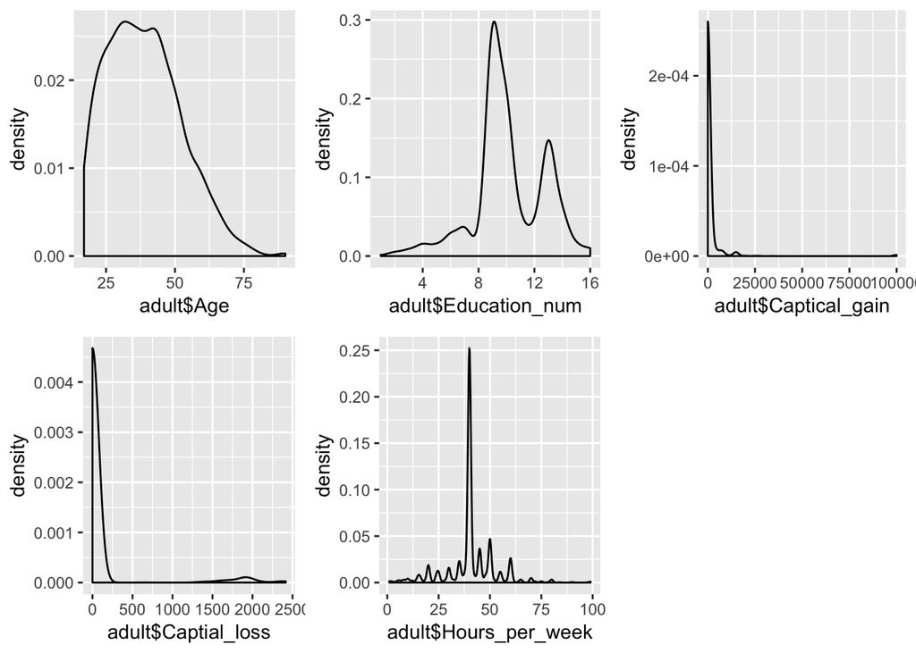

```r
# density graph in numerical variables

p1<-ggplot(adult, aes(x = adult$Age)) + geom_density()
p2<-ggplot(adult, aes(x = adult$Education_num)) + geom_density()
p3<-ggplot(adult, aes(x = adult$Captical_gain)) + geom_density()
p4<-ggplot(adult, aes(x = adult$Captial_loss)) + geom_density()
p5<-ggplot(adult, aes(x = adult$Hours_per_week)) + geom_density()
grid.arrange(p1,p2,p3,p4,p5,ncol=3)
```

```r
# how many zero value in variables
sum(adult$Captical_gain==0)
```

```
## [1] 1822
```

```r
sum(adult$Captial_loss==0)
```

```
## [1] 1899
```

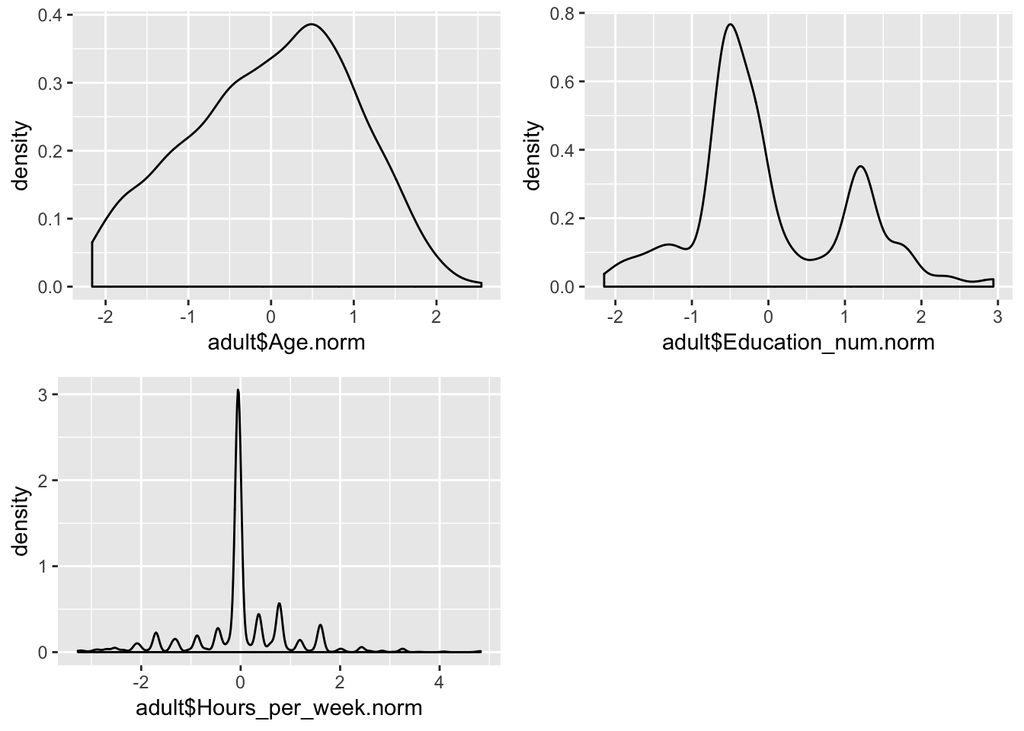

```r
# normalization of numerical variables
# Age
adult$Age.fix <- log10(adult$Age)
adult$Age.norm <- (adult$Age.fix - mean(adult$Age.fix))/sd(adult$Age.fix)
# Education_num
adult$Education_num.fix <- (adult$Education_num)^2
adult$Education_num.norm <- (adult$Education_num.fix - mean(adult$Education_num.fix))/sd(adult$Education_num.fix)
# Hours_per_week
adult$Hours_per_week.norm <- (adult$Hours_per_week - mean(adult$Hours_per_week))/sd(adult$Hours_per_week)
# Captical_gain
min_Captical_gain<-min(adult$Captical_gain)
max_Captical_gain<-max(adult$Captical_gain)
adult$Captical_gain.norm <- (adult$Captical_gain - min_Captical_gain)/(max_Captical_gain - min_Captical_gain)
# Captial_loss
min_Captial_loss<-min(adult$Captial_loss)
max_Captial_loss<-max(adult$Captial_loss)
adult$Captial_loss.norm <- (adult$Captial_loss - min_Captial_loss)/(max_Captial_loss - min_Captial_loss)
# Salary
adult$Salary.norm <- ifelse(as.numeric(adult$Salary)==1, 0, 1)

p1<-ggplot(adult, aes(x = adult$Age.norm)) + geom_density()
p2<-ggplot(adult, aes(x = adult$Education_num.norm)) + geom_density()
p3<-ggplot(adult, aes(x = adult$Hours_per_week.norm)) + geom_density()
grid.arrange(p1,p2,p3,ncol=2)
```

#### Logistic Regression Model

In this case, we apply the dataset with a Logistic Regression model with some features. Therefore, we can easily use p-value to analysis features to eliminate most unnecessary features. Then, we will ignore these three features, Fnlwgt, Race, and Native-Country; and rebuild a model with rest of features.

```r
# run on logistic regression model
adult_log_test1 <- glm(Salary ~ Age.norm + Workclass + Fnlwgt + Education + Education_num.norm + Marital_status + Occupation + Relationship + Race + Sex + Captical_gain.norm + Captial_loss.norm + Hours_per_week.norm + Native_country, family = binomial, data = adult)
summary(adult_log_test1)
```

```
##
## Call:
## glm(formula = Salary ~ Age.norm + Workclass + Fnlwgt + Education +
##     Education_num.norm + Marital_status + Occupation + Relationship +
##     Race + Sex + Captical_gain.norm + Captial_loss.norm + Hours_per_week.norm +
##     Native_country, family = binomial, data = adult)
##
## Deviance Residuals:
##     Min       1Q   Median       3Q      Max
## -2.4673  -0.4789  -0.1466   0.0000   2.9217
##
## Coefficients: (2 not defined because of singularities)
##                                             Estimate Std. Error z value
## (Intercept)                               -7.913e+00  2.087e+00  -3.792
## Age.norm                                   4.995e-01  1.084e-01   4.607
## Workclass Federal-gov                      1.216e+00  6.476e-01   1.878
## Workclass Local-gov                        7.177e-02  5.523e-01   0.130
## Workclass Private                          3.464e-01  4.975e-01   0.696
## Workclass Self-emp-inc                     1.005e+00  5.920e-01   1.698
## Workclass Self-emp-not-inc                -5.090e-01  5.574e-01  -0.913
## Workclass State-gov                        3.436e-01  6.020e-01   0.571
## Workclass Without-pay                     -1.463e+01  3.956e+03  -0.004
## Fnlwgt                                     5.154e-07  7.214e-07   0.714
## Education 11th                             3.120e-01  8.150e-01   0.383
## Education 12th                             1.208e+00  1.051e+00   1.149
## Education 1st-4th                         -1.402e+01  1.084e+03  -0.013
## Education 5th-6th                         -1.401e+01  8.703e+02  -0.016
## Education 7th-8th                          9.364e-01  8.509e-01   1.100
## Education 9th                             -1.483e+01  6.192e+02  -0.024
## Education Assoc-acdm                       2.069e+00  6.910e-01   2.994
## Education Assoc-voc                        1.606e+00  6.726e-01   2.388
## Education Bachelors                        2.130e+00  6.183e-01   3.444
## Education Doctorate                        4.724e+00  1.175e+00   4.021
## Education HS-grad                          9.583e-01  5.950e-01   1.611
## Education Masters                          1.576e+00  6.510e-01   2.421
## Education Preschool                       -1.423e+01  2.428e+03  -0.006
## Education Prof-school                      1.837e+00  7.936e-01   2.315
## Education Some-college                     1.076e+00  6.104e-01   1.763
## Education_num.norm                                NA         NA      NA
## Marital_status Married-AF-spouse          -1.205e+01  2.791e+03  -0.004
```

[output cut: 159 more lines]

```
## Native_country Taiwan                     0.764483
## Native_country Thailand                   0.410172
## Native_country Trinadad&Tobago            0.996806
## Native_country United-States              0.992710
## Native_country Yugoslavia                 0.996609
## ---
## Signif. codes:  0 '***' 0.001 '**' 0.01 '*' 0.05 '.' 0.1 ' ' 1
##
## (Dispersion parameter for binomial family taken to be 1)
##
##     Null deviance: 2246.6  on 1998  degrees of freedom
## Residual deviance: 1231.7  on 1906  degrees of freedom
## AIC: 1417.7
##
## Number of Fisher Scoring iterations: 16
```

```r
# Ignore Fnlwgt, Race, and Native-Country, ignore features causing singularities, build a new
adult_log_test2 <- glm(Salary ~ Age.norm + Workclass + Education + Marital_status + Occupation + Relationship + Sex + Captical_gain.norm + Captial_loss.norm + Hours_per_week.norm, family = binomial, data = adult)
summary(adult_log_test2)
```

```
##
## Call:
## glm(formula = Salary ~ Age.norm + Workclass + Education + Marital_status +
##     Occupation + Relationship + Sex + Captical_gain.norm + Captial_loss.norm +
##     Hours_per_week.norm, family = binomial, data = adult)
##
## Deviance Residuals:
##     Min       1Q   Median       3Q      Max
## -2.4562  -0.5228  -0.1635   0.0000   2.8573
##
## Coefficients: (1 not defined because of singularities)
##                                        Estimate Std. Error z value
## (Intercept)                            -6.85122    1.38474  -4.948
## Age.norm                                0.49413    0.10529   4.693
## Workclass Federal-gov                   1.19460    0.62654   1.907
## Workclass Local-gov                     0.06534    0.53967   0.121
## Workclass Private                       0.30308    0.48475   0.625
## Workclass Self-emp-inc                  0.94068    0.57967   1.623
## Workclass Self-emp-not-inc             -0.42415    0.54182  -0.783
## Workclass State-gov                     0.36045    0.58659   0.614
## Workclass Without-pay                 -14.40927 3956.18046  -0.004
## Education 11th                          0.30585    0.81423   0.376
## Education 12th                          1.28982    1.01661   1.269
## Education 1st-4th                     -14.42252 1071.07018  -0.013
## Education 5th-6th                     -14.55084  831.79073  -0.017
## Education 7th-8th                       0.64782    0.82852   0.782
## Education 9th                         -15.07403  615.70754  -0.024
## Education Assoc-acdm                    2.11647    0.68566   3.087
## Education Assoc-voc                     1.62143    0.66789   2.428
## Education Bachelors                     2.12375    0.61757   3.439
## Education Doctorate                     4.61729    1.11682   4.134
## Education HS-grad                       1.00542    0.59622   1.686
## Education Masters                       1.62961    0.64959   2.509
## Education Preschool                   -14.07834 2439.32949  -0.006
## Education Prof-school                   1.85236    0.78873   2.349
## Education Some-college                  1.10919    0.61060   1.817
## Marital_status Married-AF-spouse      -12.50247 2776.27035  -0.005
## Marital_status Married-civ-spouse       3.01438    1.15196   2.617
## Marital_status Married-spouse-absent   -1.56768    1.11708  -1.403
## Marital_status Never-married           -0.41087    0.35472  -1.158
```

[output cut: 74 more lines]

```
## Relationship Wife                    0.000129 ***
## Sex Male                             0.000814 ***
## Captical_gain.norm                    < 2e-16 ***
## Captial_loss.norm                    2.97e-05 ***
## Hours_per_week.norm                  1.59e-06 ***
## ---
## Signif. codes:  0 '***' 0.001 '**' 0.01 '*' 0.05 '.' 0.1 ' ' 1
##
## (Dispersion parameter for binomial family taken to be 1)
##
##     Null deviance: 2246.6  on 1998  degrees of freedom
## Residual deviance: 1270.5  on 1947  degrees of freedom
## AIC: 1374.5
##
## Number of Fisher Scoring iterations: 16
```

Hence, we use AIC method to make feature selection again. In this case, the result shows us that the model with test 2 features is already a more suitable model than test 1.

```r
# use AIC
adult_adult_logit_stepwise_backward <- stepAIC(adult_log_test2, direction = "backward")
```

```
## Start:  AIC=1374.54
## Salary ~ Age.norm + Workclass + Education + Marital_status +
##     Occupation + Relationship + Sex + Captical_gain.norm + Captial_loss.norm +
##     Hours_per_week.norm
```

```
##                       Df Deviance    AIC
## <none>                     1270.5 1374.5
## - Marital_status       6   1284.5 1376.5
## - Workclass            6   1290.7 1382.7
## - Sex                  1   1282.5 1384.5
## - Captial_loss.norm    1   1288.4 1390.4
## - Occupation          13   1315.1 1393.1
## - Age.norm             1   1293.4 1395.4
## - Relationship         5   1302.0 1396.0
## - Hours_per_week.norm  1   1294.5 1396.5
## - Education           15   1346.2 1420.2
## - Captical_gain.norm   1   1378.1 1480.1
```

```r
adult_adult_logit_stepwise_forward <- stepAIC(adult_log_test2, direction = "forward")
```

```
## Start:  AIC=1374.54
## Salary ~ Age.norm + Workclass + Education + Marital_status +
##     Occupation + Relationship + Sex + Captical_gain.norm + Captial_loss.norm +
##     Hours_per_week.norm
```

```r
# create final dataset with features
adult_df <- adult[,c("Age.norm","Workclass" , "Education" , "Marital_status" ,"Occupation" , "Relationship" ,"Sex" , "Captical_gain.norm", "Captial_loss.norm", "Hours_per_week.norm", "Salary.norm")]

summary(adult_df)
```

```
##     Age.norm                   Workclass            Education
##  Min.   :-2.1626    Private         :1381    HS-grad     :670
##  1st Qu.:-0.7538    Self-emp-not-inc: 155    Some-college:425
##  Median : 0.1084    Local-gov       : 135    Bachelors   :342
##  Mean   : 0.0000    ?               : 123    Masters     :113
##  3rd Qu.: 0.7680    Self-emp-inc    :  77    Assoc-voc   : 85
##  Max.   : 2.5427    State-gov       :  77    11th        : 81
##                    (Other)          :  51   (Other)      :283
##                 Marital_status            Occupation
##   Divorced             :274     Prof-specialty :253
##   Married-AF-spouse    :  2     Exec-managerial:245
##   Married-civ-spouse   :932     Craft-repair   :239
##   Married-spouse-absent: 27     Sales          :229
##   Never-married        :649     Adm-clerical   :221
##   Separated            : 49     Other-service  :216
##   Widowed              : 66    (Other)         :596
##           Relationship      Sex       Captical_gain.norm Captial_loss.norm
##   Husband       :810    Female: 628   Min.   :0.00000    Min.   :0.00000
##   Not-in-family :547    Male  :1371   1st Qu.:0.00000    1st Qu.:0.00000
##   Other-relative: 41                  Median :0.00000    Median :0.00000
##   Own-child     :283                  Mean   :0.01068    Mean   :0.03864
##   Unmarried     :207                  3rd Qu.:0.00000    3rd Qu.:0.00000
##   Wife          :111                  Max.   :1.00000    Max.   :1.00000
##
##  Hours_per_week.norm  Salary.norm
##  Min.   :-3.27186    Min.   :0.0000
##  1st Qu.:-0.04899    1st Qu.:0.0000
##  Median :-0.04899    Median :0.0000
##  Mean   : 0.00000    Mean   :0.2496
##  3rd Qu.: 0.36420    3rd Qu.:0.0000
##  Max.   : 4.82663    Max.   :1.0000
##
```

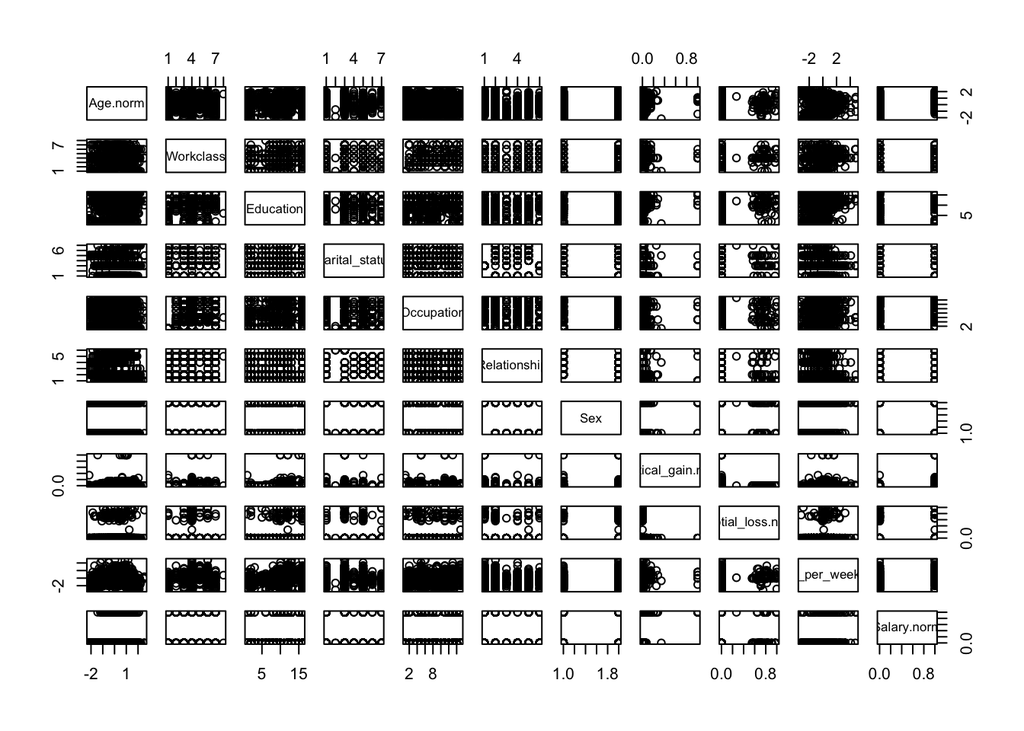

```r
plot(adult_df)
```

### Question #2

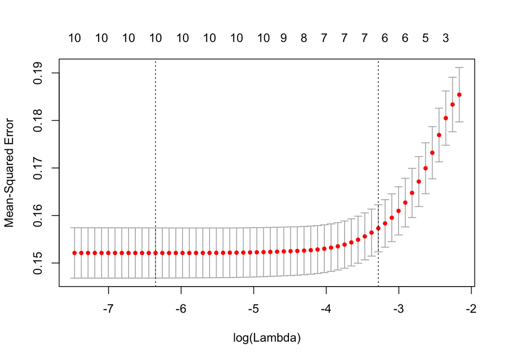

```r
# split dataset into training and testing dataset
adult_df.prep <- adult_df[, c("Age.norm", "Workclass" , "Education" , "Marital_status" ,"Occupation" , "Relationship" ,"Sex", "Captical_gain.norm", "Captial_loss.norm", "Hours_per_week.norm", "Salary.norm")]
adult_df.prep[, c("Workclass" , "Education" , "Marital_status" ,"Occupation" , "Relationship" ,"Sex")] <- lapply(adult_df.prep[, c("Workclass" , "Education" , "Marital_status" ,"Occupation" , "Relationship" ,"Sex")], as.factor)
adult_df.prep[, c("Workclass" , "Education" , "Marital_status" ,"Occupation" , "Relationship" ,"Sex")] <- lapply(adult_df.prep[, c("Workclass" , "Education" , "Marital_status" ,"Occupation" , "Relationship" ,"Sex")], as.numeric)

set.seed(123)
adult_split <- initial_split(adult_df.prep, 0.8)
adult_train_tbl <- training(adult_split)
adult_test_tbl <- testing(adult_split)

adult_vars_train <- adult_train_tbl[, c("Age.norm","Workclass" , "Education" , "Marital_status" ,"Occupation" , "Relationship" ,"Sex" ,  "Captical_gain.norm", "Captial_loss.norm","Hours_per_week.norm")]
adult_vars_test <- adult_test_tbl[, c("Age.norm","Workclass" , "Education" , "Marital_status" ,"Occupation" , "Relationship" ,"Sex" , "Captical_gain.norm", "Captial_loss.norm", "Hours_per_week.norm")]
adult_target_train <- adult_train_tbl[, c("Salary.norm")]
adult_target_test <- adult_test_tbl[, c("Salary.norm")]

# LASSO & RIDGE
set.seed(123)
adult_cv_lasso = cv.glmnet(x = as.matrix(adult_vars_train), y = as.numeric(adult_target_train), alpha=1)
plot(adult_cv_lasso, label=TRUE)
```

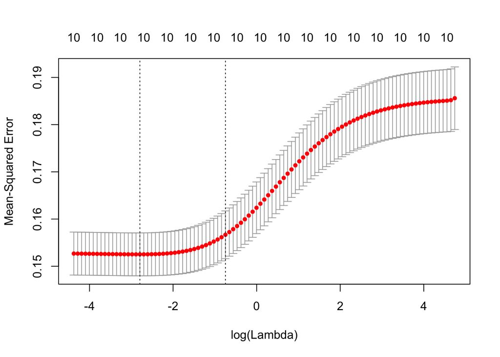

```r
adult_cv_ridge = cv.glmnet(x = as.matrix(adult_vars_train), y = as.numeric(adult_target_train), alpha=0)
plot(adult_cv_ridge, label=TRUE)
```

```r
# lambda min
bestlam_lasso <- adult_cv_lasso$lambda.min
bestlam_ridge <- adult_cv_ridge$lambda.min

lasso.pred_adult = predict(adult_cv_lasso, s = bestlam_lasso, newx = as.matrix(adult_vars_test))
adult_mse_lasso <- mean((lasso.pred_adult - adult_test_tbl$Salary)^2)

ridge.pred_adult = predict(adult_cv_ridge, s = bestlam_ridge, newx = as.matrix(adult_vars_test))
adult_mse_ridge <- mean((ridge.pred_adult - adult_test_tbl$Salary)^2)

t_lamd_mse <- matrix(c(bestlam_lasso,bestlam_ridge,adult_mse_lasso,adult_mse_ridge),ncol=2,byrow=TRUE)
colnames(t_lamd_mse) <- c("LASSO","RIDGE")
rownames(t_lamd_mse) <- c("lambda", "MSE")
as.table(t_lamd_mse)
```

```
##              LASSO       RIDGE
## lambda 0.001741717 0.061155033
## MSE    0.158073110 0.157677345
```